# Die Möwe - Die Hamburgische Staatsoper

## Sprungmarken

Zum Seiteninhalt springen

[Die Hamburgische Staatsoper](https://www.die-hamburgische-staatsoper.de/de)

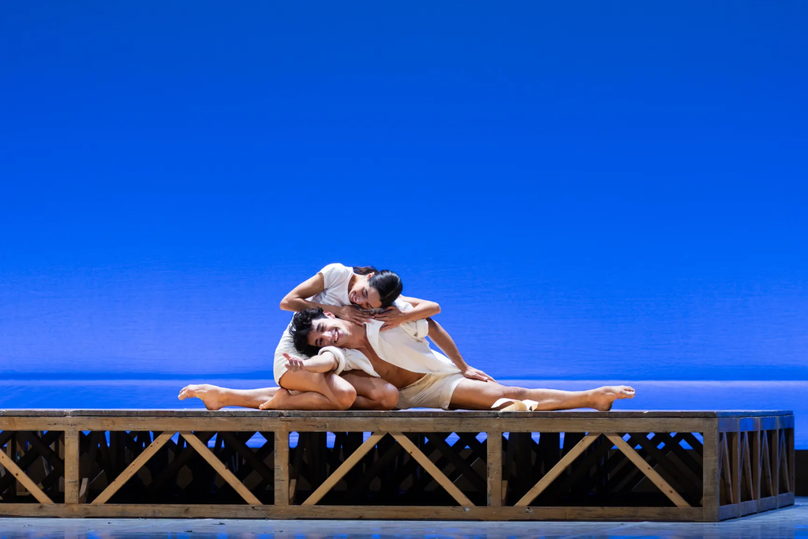

**© ×**

Kiran West

[Programm](https://hamburgballett.die-hamburgische-staatsoper.de/de/programm/) → Ballett

# Die Möwe

John Neumeier

- Do 16.10. 19:30 Tickets
- Sa 25.10. 19:30 Tickets
- Fr 3.7. 19:30 Tickets

Wie in Anton Tschechows Drama treffen auch in John Neumeiers Ballettfassung Menschen aus mehreren Generationen auf einem abgelegenen Landgut zusammen. Trotz unterschiedlicher Ansichten über das Leben, vereint sie der ewige Konflikt zwischen der Kunst und der Liebe. Neumeier verlegt die Handlung in die Welt des Tanzes und verleiht dabei jeder Figur einen repräsentativen Tanzstil. Wiederaufnahme im Herbst 2025 anlässlich des 50. Todestags von Dmitri Schostakowitsch.

## Werkangaben

Ballett von John Neumeier frei nach Anton Tschechow  
Uraufführung: Hamburg Ballett, Hamburg, 16. Juni 2002

[interactive chart not shown]

## Besetzung

- Choreografie

  [John Neumeier](https://hamburgballett.die-hamburgische-staatsoper.de/de/personen/707-john-neumeier)
- Musik

  Dmitri Schostakowitsch

  Piotr Illich Tschaikowsky

  Alexander Skrjabin

  Evelyn Glennie
- Bühnenbild und Kostüme

  [John Neumeier](https://hamburgballett.die-hamburgische-staatsoper.de/de/personen/707-john-neumeier)
- Irina Nikolajewna Arkadina

  [Anna Laudere](https://hamburgballett.die-hamburgische-staatsoper.de/de/personen/3269-anna-laudere)
  - 16.10.25

  [Ida Praetorius](https://hamburgballett.die-hamburgische-staatsoper.de/de/personen/2147485344-ida-praetorius)
  - 25.10.25
- Konstantin (Kostja)

  [Louis Musin](https://hamburgballett.die-hamburgische-staatsoper.de/de/personen/2147485316-louis-musin)
  - 16.10.25

  [Caspar Sasse](https://hamburgballett.die-hamburgische-staatsoper.de/de/personen/2147485568-caspar-sasse)
  - 25.10.25
- Pjotr Nikolajewitsch Sorin

  [Alexandre Riabko](https://hamburgballett.die-hamburgische-staatsoper.de/de/personen/1067-alexandre-riabko)
  - 16.10.25

  [Louis Haslach](https://hamburgballett.die-hamburgische-staatsoper.de/de/personen/2147484881-louis-haslach)
  - 25.10.25
- Boris Alexejewitsch Trigorin

  [Matias Oberlin](https://hamburgballett.die-hamburgische-staatsoper.de/de/personen/2147484504-matias-oberlin)
  - 16.10.25

  [Daniele Bonelli](https://hamburgballett.die-hamburgische-staatsoper.de/de/personen/2147485680-daniele-bonelli)
  - 25.10.25
- Nina Michajlowna Saretschnaja

  [Ana Torrequebrada](https://hamburgballett.die-hamburgische-staatsoper.de/de/personen/2147485073-ana-torrequebrada)
  - 16.10.25

  [Francesca Harvey](https://hamburgballett.die-hamburgische-staatsoper.de/de/personen/2147485078-francesca-harvey)
  - 25.10.25
- Jewgenij Sergejewitsch Dorn

  [Joaquin Angelucci](https://hamburgballett.die-hamburgische-staatsoper.de/de/personen/2147485676-joaquin-angelucci)
  - 16.10.25

  [Florian Pohl](https://hamburgballett.die-hamburgische-staatsoper.de/de/personen/2147484505-florian-pohl)
  - 25.10.25
- Semjon Semjonowitsch Medwedenko

  [Lennard Giesenberg](https://hamburgballett.die-hamburgische-staatsoper.de/de/personen/2147485407-lennard-giesenberg)
  - 16.10.25

  [Javier Monreal](https://hamburgballett.die-hamburgische-staatsoper.de/de/personen/2147485403-javier-monreal)
  - 25.10.25
- Ilja Afanassewitsch Schamrajew

  [Florian Pohl](https://hamburgballett.die-hamburgische-staatsoper.de/de/personen/2147484505-florian-pohl)
  - 16.10.25

  Pepijn Gelderman
  - 25.10.25
- Polina Andrejewna

  [Hayley Page](https://hamburgballett.die-hamburgische-staatsoper.de/de/personen/2147484469-hayley-page)
  - 16.10.25

  [Ida-Sofia Stempelmann](https://hamburgballett.die-hamburgische-staatsoper.de/de/personen/2147485954-ida-sofia-stempelmann)
  - 25.10.25
- Mascha

  [Xue Lin](https://hamburgballett.die-hamburgische-staatsoper.de/de/personen/2147484486-xue-lin)
  - 16.10.25

  [Charlotte Larzelere](https://hamburgballett.die-hamburgische-staatsoper.de/de/personen/2147484943-charlotte-larzelere)
  - 25.10.25
- Musikalische Leitung

  [Nathan Brock](https://hamburgballett.die-hamburgische-staatsoper.de/de/personen/39912273-nathan-brock)
- Klavier

  [Petar Kostov](https://hamburgballett.die-hamburgische-staatsoper.de/de/personen/39915456-petar-kostov)
  - 16.10.25

  Ondřej Rudčenko
  - 25.10.25
- Ensemble

  Hamburg Ballett
- Orchester

  [Philharmonisches Staatsorchester Hamburg](https://hamburgballett.die-hamburgische-staatsoper.de/de/personen/1929-philharmonisches-staatsorchester-hamburg)

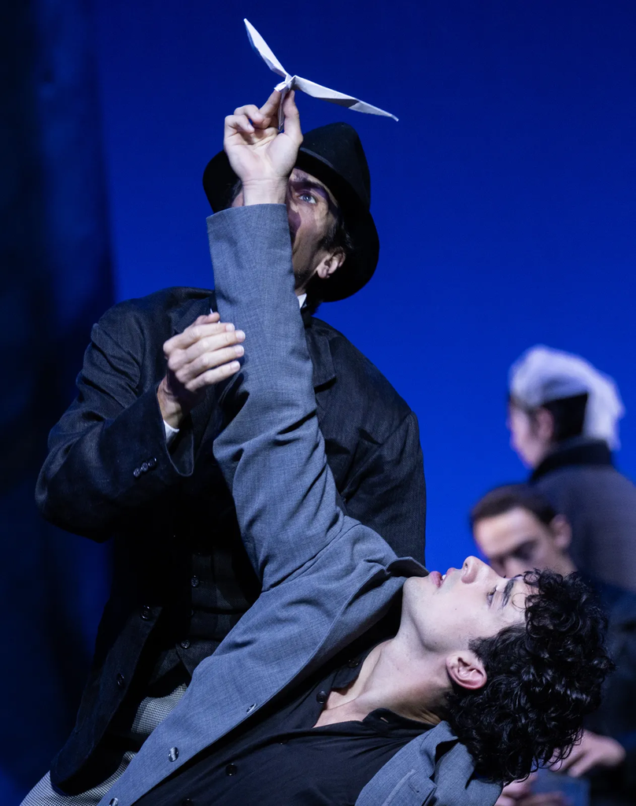

- **© ×**

  Kiran West

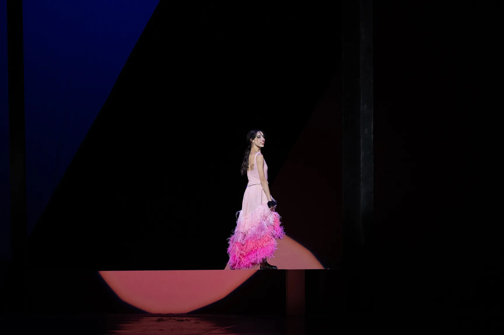

- **© ×**

  Kiran West

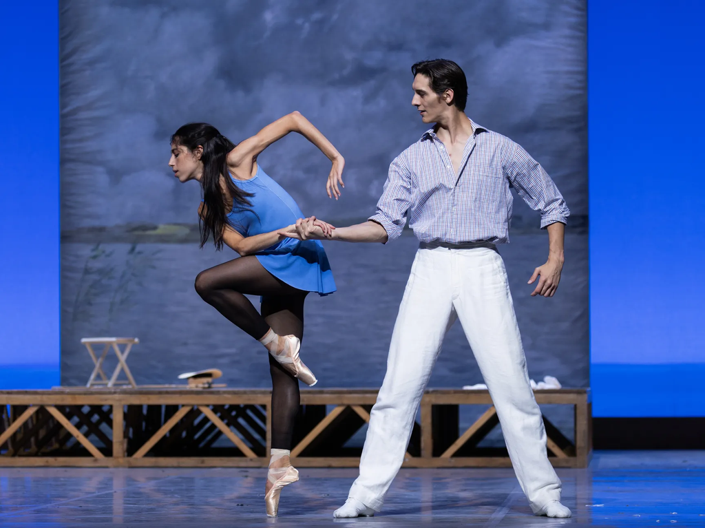

- **© ×**

  Kiran West

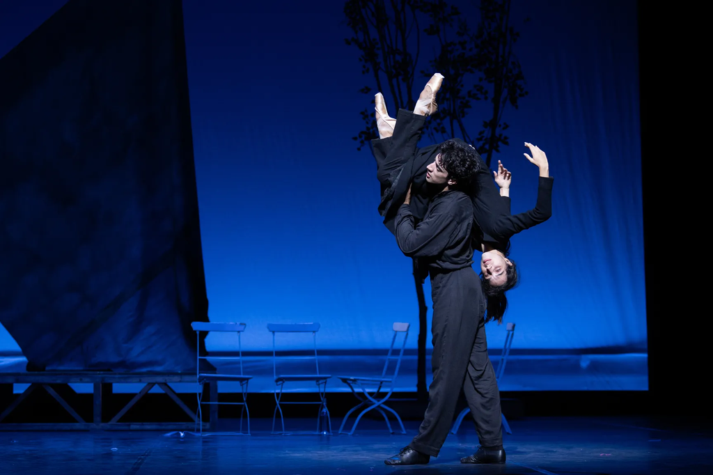

- **© ×**

  Kiran West

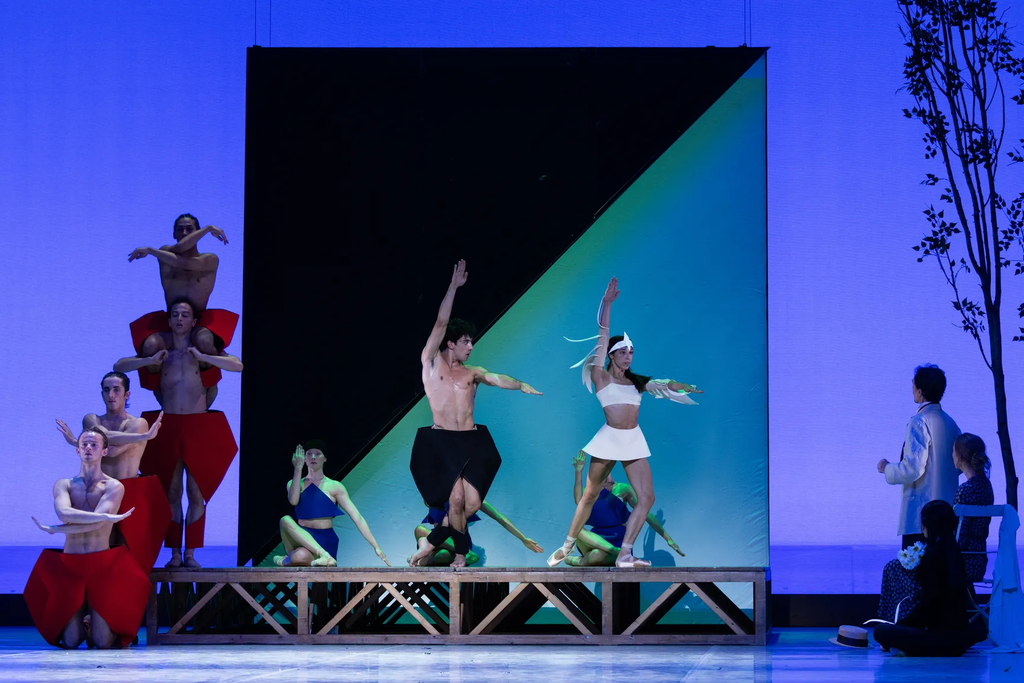

- **© ×**

  Kiran West

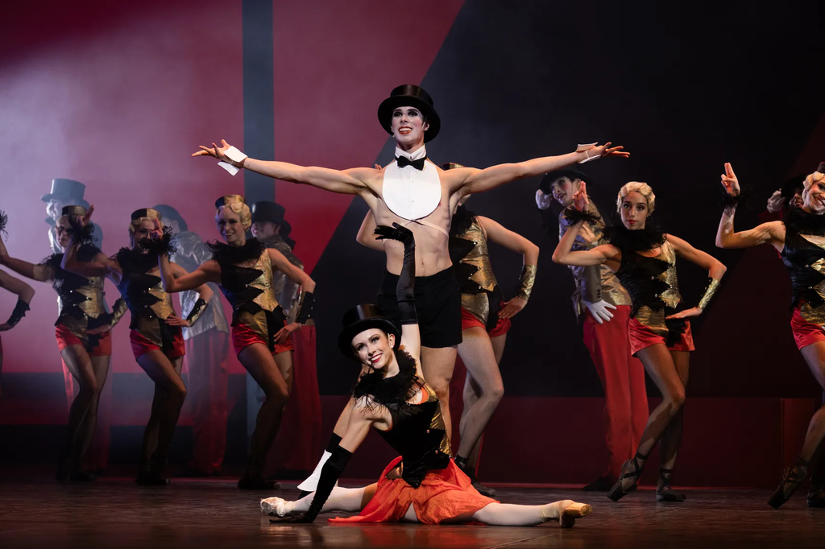

- **© ×**

  Kiran West

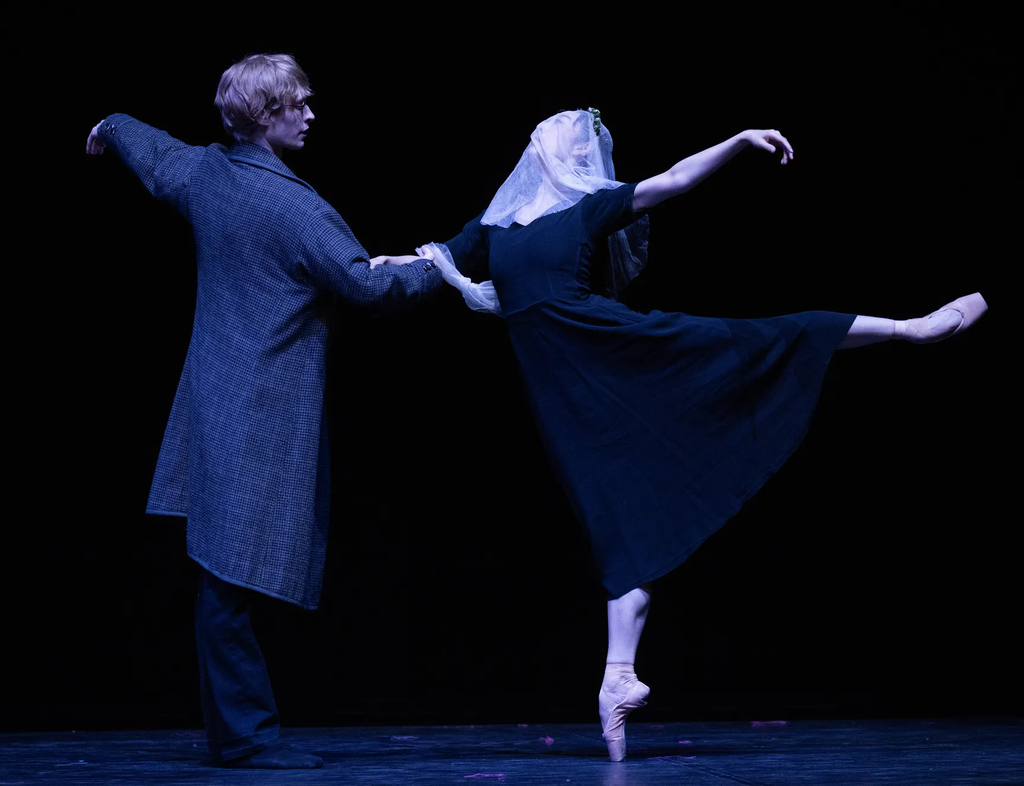

- **© ×**

  Kiran West

## Das Stück

Auf einem abgelegenen Landgut treffen Menschen aus mehreren Generationen zusammen und bringen unterschiedliche Ansichten über das Leben und die Kunst mit. Viele von ihnen sind Künstler:innen oder streben danach, es zu werden, doch niemand ist glücklich. Das freigeistige Leben, das von Konventionen losgelöst ist, existiert lediglich als Symbol, verkörpert durch eine Möwe, die von einer der Hauptfiguren grundlos abgeschossen wird. In seiner Adaption von Anton Tschechows "Die Möwe" verlegt John Neumeier die Handlung aus der Welt der Literatur in die Welt des Tanzes. Anstelle literarischer Diskussionen drücken sich die Figuren durch verschiedene Tanzstile aus. Der junge Kostja, auf der Suche nach neuen Ausdrucksformen, nutzt die Sprache des expressionistischen modernen Tanzes. Seine Mutter Arkadina blickt auf eine glanzvolle Karriere als Primaballerina zurück und repräsentiert das klassische Ballett. Nina hingegen träumt von einer großen Theaterkarriere, doch ihre Beziehung zum erfolgreichen Choreografen Trigorin zerbricht schnell, und in Moskau kommt sie über ein Engagement als Revuetänzerin nicht hinaus. Trotz dieser Rückschläge gewinnt Nina an Stärke; durch ihre eigenen Entscheidungen entkommt sie der Öde der Provinz.  
Neumeier fokussiert sich auf den zentralen Konflikt des Stücks: das Spannungsverhältnis zwischen Kunst und Liebe. Die Figuren suchen Trost bei anderen, doch die Liebe bietet keinen Ausweg: Sie bleibt entweder bloße Konvention oder pure Illusion. Tschechows "Die Möwe" ist reich an vielschichtigen Dialogen und psychologisch komplexen Figuren. Neumeier greift dieses Panorama auf und macht mit unterschiedlichen Ausdrucksformen in seinem Ballett sichtbar, was im Drama oft nur Andeutung bleibt. Anlässlich des 50. Todestags von Dmitri Schostakowitsch kehrt das Ballett als Wiederaufnahme ins Repertoire des Hamburg Ballett zurück.

Rahmenprogramm

[figure not shown]

Das Vermittlungsprogramm der Hamburgischen Staatsoper

[Mehr dazu](https://google.com/ballett)

**Inhaltsangabe − +**

1. AKT

Kostjas Mutter, die berühmte Primaballerina Irina Arkadina ist mit ihrem Liebhaber, dem Choreografen Boris Trigorin in der Sommerfrische. Unter den Gästen von Kostjas Vorstellung sind: Ilja Schamrajew, Gutsverwalter bei Sorin, seine Frau Polina, ihre Tochter Mascha, der Arzt Dr. Dorn und der Dorfschullehrer Semjon Medwedenko.  
Medwedenko liebt Mascha. Mascha liebt Kostja. Kostja liebt Nina. Nina verliebt sich in Trigorin. Trigorin liebt Arkadina und ist von Nina fasziniert. Arkadina liebt Trigorin. Polina liebt Dr. Dorn.

Kostjas Tanzstück "Die Seele der Möwe"

Musik von der anderen Seite des Sees - Arkadina erinnert sich an eine Rolle

Arkadina spricht mit ihrem Sohn Kostja  
Trigorin unterrichtet Nina

Kartenspiel und Zeitvertreib

Eifersucht und Entscheidungen  
Kostjas Traum-Tänze

2. AKT

Moskau  
Im Revuetheater: Nina ist eine in der Reihe der Tänzerinnen

Nina begegnet einem veränderten Trigorin -  
Die Revue geht weiter

Kostjas Skizzenbuch - Traum-Tänze

Ninas Polka

Im Kaiserlichen Theater: Trigorins Ballett "Der Tod der Möwe"

Mascha entscheidet sich Medwedenko zu heiraten

Ninas Brief an Kostja

Herbst-Garten: Sorin erleidet einen Schwächeanfall

Arkadinas Besuch - Ein traurig bedrückendes Hochzeitsfest

Ninas Erscheinung - Ninas Abschied

Kostjas Traum-Tänze gehen zu Ende

**Historische Stückinfos − +**

PREMIERE:  
Hamburg Ballett, Hamburg, 16. Juni 2002  
ORIGINALBESETZUNG:  
Irina Nikolajewna Arkadina: Anna Polikarpova  
Konstantin (Kostja) Grawilowitsch Trepljow: Ivan Urban (für Jirí Bubenícek)  
Pjotr Nikolajewitsch Sorin: Lloyd Riggins  
Boris Alexejewitsch Trigorin: Otto Bubenícek  
Nina Michajlowna Saretschnaja: Heather Jurgensen  
Jewgenij Sergejewitsch Dorn: Sébastien Thill  
Semjon Semjonowitsch Medwedenko: Peter Dingle  
Ilja Afanassewitsch Schamrajew: Yaroslav Ivanenko  
Polina Andrejewna: Niurka Moredo  
Mascha: Joëlle Boulogne  
GASTSPIEL:  
2018 Wien  
IM REPERTOIRE:  
Finnisches Nationalballett  
Stanislawski- und Nemirowitsch-Dantschenko-Musiktheater  
The National Ballet of Canada

**Besetzungszettel Archiv − +**

Besetzungszettel Die Möwe 21.09.2025

PDF · 63 KB

Besetzungszettel Die Möwe 22.09.2025

PDF · 63 KB

Besetzungszettel Die Möwe 25.09.2025

PDF · 63 KB

Besetzungszettel Die Möwe 28.09.2025

PDF · 63 KB

- Mit: [Anna Laudere](https://hamburgballett.die-hamburgische-staatsoper.de/de/personen/3269-anna-laudere), [Louis Musin](https://hamburgballett.die-hamburgische-staatsoper.de/de/personen/2147485316-louis-musin), [Alexandre Riabko](https://hamburgballett.die-hamburgische-staatsoper.de/de/personen/1067-alexandre-riabko), [Matias Oberlin](https://hamburgballett.die-hamburgische-staatsoper.de/de/personen/2147484504-matias-oberlin), [Ana Torrequebrada](https://hamburgballett.die-hamburgische-staatsoper.de/de/personen/2147485073-ana-torrequebrada), [Joaquin Angelucci](https://hamburgballett.die-hamburgische-staatsoper.de/de/personen/2147485676-joaquin-angelucci), [Lennard Giesenberg](https://hamburgballett.die-hamburgische-staatsoper.de/de/personen/2147485407-lennard-giesenberg), [Florian Pohl](https://hamburgballett.die-hamburgische-staatsoper.de/de/personen/2147484505-florian-pohl), [Hayley Page](https://hamburgballett.die-hamburgische-staatsoper.de/de/personen/2147484469-hayley-page), [Xue Lin](https://hamburgballett.die-hamburgische-staatsoper.de/de/personen/2147484486-xue-lin), [Nathan Brock](https://hamburgballett.die-hamburgische-staatsoper.de/de/personen/39912273-nathan-brock), [Petar Kostov](https://hamburgballett.die-hamburgische-staatsoper.de/de/personen/39915456-petar-kostov), Hamburg Ballett, [Philharmonisches Staatsorchester Hamburg](https://hamburgballett.die-hamburgische-staatsoper.de/de/personen/1929-philharmonisches-staatsorchester-hamburg)

  [Details](https://hamburgballett.die-hamburgische-staatsoper.de/de/programm/ballett/485-die-moewe)
- Mit: [Ida Praetorius](https://hamburgballett.die-hamburgische-staatsoper.de/de/personen/2147485344-ida-praetorius), [Caspar Sasse](https://hamburgballett.die-hamburgische-staatsoper.de/de/personen/2147485568-caspar-sasse), [Louis Haslach](https://hamburgballett.die-hamburgische-staatsoper.de/de/personen/2147484881-louis-haslach), [Daniele Bonelli](https://hamburgballett.die-hamburgische-staatsoper.de/de/personen/2147485680-daniele-bonelli), [Francesca Harvey](https://hamburgballett.die-hamburgische-staatsoper.de/de/personen/2147485078-francesca-harvey), [Florian Pohl](https://hamburgballett.die-hamburgische-staatsoper.de/de/personen/2147484505-florian-pohl), [Javier Monreal](https://hamburgballett.die-hamburgische-staatsoper.de/de/personen/2147485403-javier-monreal), Pepijn Gelderman, [Ida-Sofia Stempelmann](https://hamburgballett.die-hamburgische-staatsoper.de/de/personen/2147485954-ida-sofia-stempelmann), [Charlotte Larzelere](https://hamburgballett.die-hamburgische-staatsoper.de/de/personen/2147484943-charlotte-larzelere), [Nathan Brock](https://hamburgballett.die-hamburgische-staatsoper.de/de/personen/39912273-nathan-brock), Ondřej Rudčenko, Hamburg Ballett, [Philharmonisches Staatsorchester Hamburg](https://hamburgballett.die-hamburgische-staatsoper.de/de/personen/1929-philharmonisches-staatsorchester-hamburg)

  [Wochentags-Abo (VTg2)](https://www.die-hamburgische-staatsoper.de/de/service/abos#wochentags-abos) · 7€ 15€ 23€ 41€ 62€ 77€ 91€ 103€ 115€ 129€

  [Details](https://hamburgballett.die-hamburgische-staatsoper.de/de/programm/ballett/485-die-moewe)
- Mit: [Nathan Brock](https://hamburgballett.die-hamburgische-staatsoper.de/de/personen/39912273-nathan-brock), Hamburg Ballett, [Philharmonisches Staatsorchester Hamburg](https://hamburgballett.die-hamburgische-staatsoper.de/de/personen/1929-philharmonisches-staatsorchester-hamburg)

  [Wochentags-Abo (Fr2)](https://www.die-hamburgische-staatsoper.de/de/service/abos#wochentags-abos) · 7€ 15€ 23€ 41€ 62€ 77€ 91€ 103€ 115€ 129€

  [Details](https://hamburgballett.die-hamburgische-staatsoper.de/de/programm/ballett/485-die-moewe)

[interactive chart not shown]